# **Forecasting Sales Revenue**

# **Machine Learning: Random Forest Regressor, Gradient Boosting Regressor**

### **+ RandomizedSearch + HugginFace + jobLib + Docker + Flask + StreamLit**

**Keys**: #EDA #HuggingFace #RandomForestRegressor #GradientBoostingRegressor #Flask #Streamlit #JobLib #jsonify #Docker

### **Josue Quiros Batista**

[figure not shown]

- Overview of the Dataset
- Exploratory Data Analysis (EDA)
- Univariate Analysis
- Bivariate Analysis
- Data Pre-processing
- Feature Engineering
- Context proxies
- Data Preparation for modeling
- Model Evaluation Criterion
- Models: Random Forest Regressor and Gradient Boosting Regressor
- Model Performance Improvement - Hyperparameter Tuning
- Model Performance Comparison, Final Model Selection, and Serialization
- Actionable Insights and Business Recommendations derived from this model

## **Business Context**

A sales forecast is a prediction of future sales revenue based on historical data, industry trends, and the status of the current sales pipeline. Businesses use the sales forecast to estimate weekly, monthly, quarterly, and annual sales totals. A company needs to make an accurate sales forecast as it adds value across an organization and helps the different verticals to chalk out their future course of action.

Forecasting helps an organization plan its sales operations by region and provides valuable insights to the supply chain team regarding the procurement of goods and materials. An accurate sales forecast process has many benefits which include improved decision-making about the future and reduction of sales pipeline and forecast risks. Moreover, it helps to reduce the time spent in planning territory coverage and establish benchmarks that can be used to assess trends in the future.

## **Objective**

SuperKart is a retail chain operating supermarkets and food marts across various tier cities, offering a wide range of products. To optimize its inventory management and make informed decisions around regional sales strategies, SuperKart wants to accurately forecast the sales revenue of its outlets for the upcoming quarter.

To operationalize these insights at scale, the company has partnered with a data science firm—not just to build a predictive model based on historical sales data, but to develop and deploy a robust forecasting solution that can be integrated into SuperKart’s decision-making systems and used across its network of stores.

## **Actionable Insights and Business Recommendations derived from this model**

### **Insights from the analysis conducted**

**Interpretation of metrics**

- **RMSE** (Root Mean Squared Error)

  On average, predictions deviate by 621 USD from the actual sales.
- **MAE** (Mean Absolute Error) On average, the absolute difference between predicted and actual sales is 489.71 USD
- **R-squared**: About 66.5% of the variance in sales is explained by the model.
- **MAPE** (Mean Absolute Percentage Error): On average, the predictions are off by 16.7% of the actual sales value.
- **Evaluation**
  - Product_Id: FD1961
  - Weight: 9.45
  - Sugar content: Low Sugar
  - Allocated area: 0.047
  - Type: Snack foods
  - MRP: 95.95
  - Sold in a Food Mart
  - **Product_Store_Sales_Total = 1684.82 USD**

Based on the trained model:

- The actual sales of product FD1961 in OUT002 were **1,684.82 USD**
- The forecasted sales from the selected model were **1,736 USD**.
- Absolute Error: |1736 - 1684.82| = **51.18 USD**
- Percentage Error: (51.18 / 1684.82) × 100 = **3.03%**

**In this case, the error was much lower than average, indicating an excellent performance.**

- With a MAPE of 16.7%, our model generally predicts sales within ±17% of actual values. The R Squared of 66.5% shows it successfully identifies many of the trends in the data, though improvements are possible, through more detailed analysis and by evaluating alternative models or further fine-tuning hyperparameters. **Nevertheless, this level of accuracy is generally sufficient for inventory, purchasing, and marketing decisions for most products.**

### **Business recommendations**

- **Fruits and vegetables** represent the highest-selling product category, accounting for 14.3% of all products sold and generating the largest revenue at **4,300,833.27 USD**. However, due to their seasonal nature, some produce items may not always be consistently available.

  Marketing efforts and product selections should match the local purchasing power in each zone. This strategy aims to boost sales of products genuinely appealing to the local demographic. It is recommended that Key Performance Indicators (KPIs) specific to each Store Type be developed to effectively measure these efforts.

  This approach could also benefit from utilizing "Context Proxies," which aim to use a derived variable to indirectly represent its associated variable. For instance, calculating the average sales per store could indirectly reflect each location's capacity to generate profit, encompassing both the store itself and its surrounding area (e.g., the socio-economic status of the surrounding area)).
- An interesting finding is that despite the majority of products sold being low in sugar, all sugar content categories generate very similar revenues. In other words, the fact that over 50% of products are low in sugar does not translate to higher sales compared to products with a regular sugar level or sugar-free products, at least when interpreting the median values.

  This could mean that products with a regular sugar level might sell well, perhaps even better than low-sugar options. This is because customers actively seek these products, even if they are not the predominant items offered in stores.
- Finally, it would be beneficial to begin recording data on the seasonal sales peaks for each product category. The aim is to forecast sales more accurately based on this information. Additionally, a marketing strategy that includes discounts and promotions for these products at specific times of the year could be developed.

#### **Used libraries**

- Numpy
- Pandas
- Scikit-learn
- Matplotlib
- Seaborn
- joblib
- Huggingface

```python
_data = r"/content/SuperKart.csv"
#_data = r"G:\Mi unidad\Documentos\Data Science\"
_data_original = pd.read_csv(_data)
_data_copy = _data_original.copy()
```

# **Data Overview**

```python
_data_copy.head()
```

|  | Product_Id | Product_Weight | Product_Sugar_Content | Product_Allocated_Area | Product_Type | Product_MRP | Store_Id | Store_Establishment_Year | Store_Size | Store_Location_City_Type | Store_Type | Product_Store_Sales_Total |
| --- | --- | --- | --- | --- | --- | --- | --- | --- | --- | --- | --- | --- |
| 0 | FD6114 | 12.66 | Low Sugar | 0.027 | Frozen Foods | 117.08 | OUT004 | 2009 | Medium | Tier 2 | Supermarket Type2 | 2842.40 |
| 1 | FD7839 | 16.54 | Low Sugar | 0.144 | Dairy | 171.43 | OUT003 | 1999 | Medium | Tier 1 | Departmental Store | 4830.02 |
| 2 | FD5075 | 14.28 | Regular | 0.031 | Canned | 162.08 | OUT001 | 1987 | High | Tier 2 | Supermarket Type1 | 4130.16 |
| 3 | FD8233 | 12.10 | Low Sugar | 0.112 | Baking Goods | 186.31 | OUT001 | 1987 | High | Tier 2 | Supermarket Type1 | 4132.18 |
| 4 | NC1180 | 9.57 | No Sugar | 0.010 | Health and Hygiene | 123.67 | OUT002 | 1998 | Small | Tier 3 | Food Mart | 2279.36 |

## **Shape**

```python
print(_data_copy.shape)
print("There are", _data_copy.shape[0], 'rows and', _data_copy.shape[1], "columns.")
```

```
(8763, 12)
There are 8763 rows and 12 columns.
```

## **Data types**

```python
_data_copy.info()
```

```
<class 'pandas.core.frame.DataFrame'>
RangeIndex: 8763 entries, 0 to 8762
Data columns (total 12 columns):
 #   Column                     Non-Null Count  Dtype
---  ------                     --------------  -----
 0   Product_Id                 8763 non-null   object
 1   Product_Weight             8763 non-null   float64
 2   Product_Sugar_Content      8763 non-null   object
 3   Product_Allocated_Area     8763 non-null   float64
 4   Product_Type               8763 non-null   object
 5   Product_MRP                8763 non-null   float64
 6   Store_Id                   8763 non-null   object
 7   Store_Establishment_Year   8763 non-null   int64
 8   Store_Size                 8763 non-null   object
 9   Store_Location_City_Type   8763 non-null   object
 10  Store_Type                 8763 non-null   object
 11  Product_Store_Sales_Total  8763 non-null   float64
dtypes: float64(4), int64(1), object(7)
memory usage: 821.7+ KB
```

## **Statistical summary**

```python
_data_copy.describe(include='all')
```

|  | Product_Id | Product_Weight | Product_Sugar_Content | Product_Allocated_Area | Product_Type | Product_MRP | Store_Id | Store_Establishment_Year | Store_Size | Store_Location_City_Type | Store_Type | Product_Store_Sales_Total |
| --- | --- | --- | --- | --- | --- | --- | --- | --- | --- | --- | --- | --- |
| count | 8763 | 8763.000000 | 8763 | 8763.000000 | 8763 | 8763.000000 | 8763 | 8763.000000 | 8763 | 8763 | 8763 | 8763.000000 |
| unique | 8763 | NaN | 4 | NaN | 16 | NaN | 4 | NaN | 3 | 3 | 4 | NaN |
| top | FD306 | NaN | Low Sugar | NaN | Fruits and Vegetables | NaN | OUT004 | NaN | Medium | Tier 2 | Supermarket Type2 | NaN |
| freq | 1 | NaN | 4885 | NaN | 1249 | NaN | 4676 | NaN | 6025 | 6262 | 4676 | NaN |
| mean | NaN | 12.653792 | NaN | 0.068786 | NaN | 147.032539 | NaN | 2002.032751 | NaN | NaN | NaN | 3464.003640 |
| std | NaN | 2.217320 | NaN | 0.048204 | NaN | 30.694110 | NaN | 8.388381 | NaN | NaN | NaN | 1065.630494 |
| min | NaN | 4.000000 | NaN | 0.004000 | NaN | 31.000000 | NaN | 1987.000000 | NaN | NaN | NaN | 33.000000 |
| 25% | NaN | 11.150000 | NaN | 0.031000 | NaN | 126.160000 | NaN | 1998.000000 | NaN | NaN | NaN | 2761.715000 |
| 50% | NaN | 12.660000 | NaN | 0.056000 | NaN | 146.740000 | NaN | 2009.000000 | NaN | NaN | NaN | 3452.340000 |
| 75% | NaN | 14.180000 | NaN | 0.096000 | NaN | 167.585000 | NaN | 2009.000000 | NaN | NaN | NaN | 4145.165000 |
| max | NaN | 22.000000 | NaN | 0.298000 | NaN | 266.000000 | NaN | 2009.000000 | NaN | NaN | NaN | 8000.000000 |

### **Observations**

**Let's check the count of each unique category in each of the categorical variables**

Convert object variables to categorical

```python
_data_copy["Product_Sugar_Content"] = _data_copy["Product_Sugar_Content"].astype("category")
_data_copy["Product_Type"] = _data_copy["Product_Type"].astype("category")
_data_copy["Store_Size"] = _data_copy["Store_Size"].astype("category")
_data_copy["Store_Location_City_Type"] = _data_copy["Store_Location_City_Type"].astype("category")
_data_copy["Store_Type"] = _data_copy["Store_Type"].astype("category")
```

### **Observations**:

In order to improve memory usage, get faster operations and improved interactions with models

**Check the count of instances on each category**

```python
_cat = _data_copy.select_dtypes(include=['category']).columns.tolist()

for column in _cat:
    print(_data_copy[column].value_counts())
    print("-" * 25)
```

```
Product_Sugar_Content
Low Sugar    4885
Regular      2251
No Sugar     1519
reg           108
Name: count, dtype: int64
-------------------------
Product_Type
Fruits and Vegetables    1249
Snack Foods              1149
Frozen Foods              811
Dairy                     796
Household                 740
Baking Goods              716
Canned                    677
Health and Hygiene        628
Meat                      618
Soft Drinks               519
Breads                    200
Hard Drinks               186
Others                    151
Starchy Foods             141
Breakfast                 106
Seafood                    76
Name: count, dtype: int64
-------------------------
Store_Size
Medium    6025
High      1586
Small     1152
Name: count, dtype: int64
-------------------------
Store_Location_City_Type
Tier 2    6262
Tier 1    1349
Tier 3    1152
Name: count, dtype: int64
-------------------------
Store_Type
Supermarket Type2     4676
Supermarket Type1     1586
Departmental Store    1349
Food Mart             1152
Name: count, dtype: int64
-------------------------
```

### **Observations**

```python
for _variable in _cat:
  print(_data_copy[_variable].unique())
```

```
['Low Sugar', 'Regular', 'No Sugar', 'reg']
Categories (4, object): ['Low Sugar', 'No Sugar', 'Regular', 'reg']
['Frozen Foods', 'Dairy', 'Canned', 'Baking Goods', 'Health and Hygiene', ..., 'Soft Drinks', 'Breakfast', 'Others', 'Starchy Foods', 'Seafood']
Length: 16
Categories (16, object): ['Baking Goods', 'Breads', 'Breakfast', 'Canned', ..., 'Seafood', 'Snack Foods',
                          'Soft Drinks', 'Starchy Foods']
['Medium', 'High', 'Small']
Categories (3, object): ['High', 'Medium', 'Small']
['Tier 2', 'Tier 1', 'Tier 3']
Categories (3, object): ['Tier 1', 'Tier 2', 'Tier 3']
['Supermarket Type2', 'Departmental Store', 'Supermarket Type1', 'Food Mart']
Categories (4, object): ['Departmental Store', 'Food Mart', 'Supermarket Type1', 'Supermarket Type2']
```

**Numerical features**

```python
_num_col = _data_copy.select_dtypes(include=np.number).columns.tolist()
for _variable in _num_col:
  print(_variable, ": ", len(_data_copy[_variable].unique()))
```

```
Product_Weight :  1113
Product_Allocated_Area :  228
Product_MRP :  6100
Store_Establishment_Year :  4
Product_Store_Sales_Total :  8668
```

### **Observations**

- 1,113 distinct weights have been observed.
- There are **6,100 different prices.**

**Duplicate value check**

```python
print("There are",_data_copy.duplicated().sum(), "duplicated rows")
```

```
There are 0 duplicated rows
```

**Missing value treatment (if needed)**

```python
_null_values = _data_copy.isnull().sum()
print(_null_values[_null_values > 0])
```

```
Series([], dtype: int64)
```

### **Observations**

There are no null or missing values. Imputation is not necessary.

# **Exploratory Data Analysis (EDA)**

## Univariate Analysis

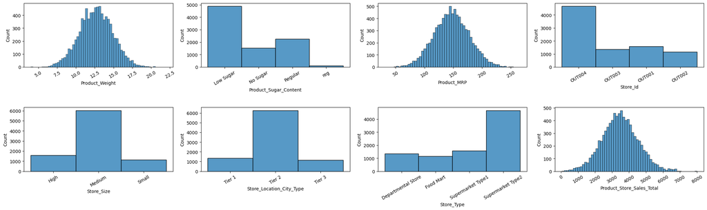

```python
plt.figure(figsize=(22, 12))
_columns = ['Product_Weight','Product_Sugar_Content','Product_MRP',
            'Store_Id','Store_Size','Store_Location_City_Type','Store_Type','Product_Store_Sales_Total']
for _cont, _variable in enumerate(_columns):
    plt.subplot(4, 4, _cont+1)
    sns.histplot(data=_data_copy, x=_variable)
    plt.xticks(rotation=30)
    plt.tight_layout();
```

### **Observations**

- The weight of each product, the maximum retail price of each product and the total revenue generated by the sale of a particular product in a particular store exhibit a normal distribution.
- This dataset represents products sold in only four stores, which are identified by their respective "ID" feature.
- **Additional findings follow.**

**1. Product_Weight - weight of each product**

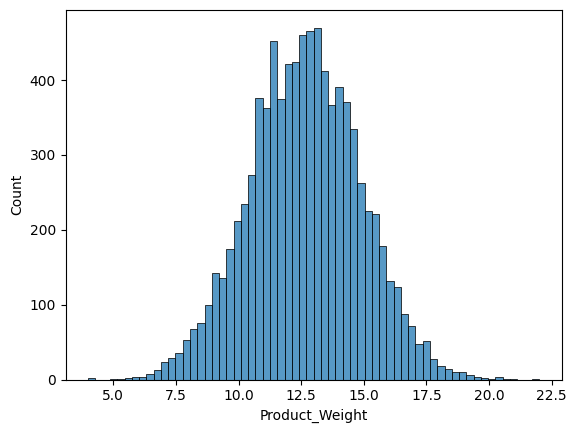

```python
sns.histplot(data=_data_copy, x='Product_Weight');
```

### **Observations**

- This variable exhibits a normal distribution, readily identifiable by its symmetrical bell shape. Data points are concentrated around a central value, with their frequency decreasing as they deviate from this center. The highest concentration of product weights is observed between **12 lb and 13 lb**, representing the most frequent weight range.

**2. Product_Sugar_Content - sugar content of each product**

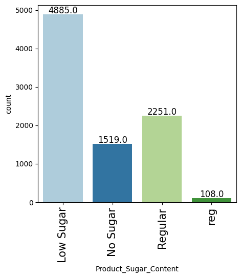

```python
labeled_barplot(_data_copy, "Product_Sugar_Content")
```

```python
_percentage_types = _data_copy['Product_Sugar_Content'].value_counts(normalize=True, sort=False)*100
_percentage_types.round(1)
```

| Product_Sugar_Content | proportion |
| --- | --- |
| Low Sugar | 55.7 |
| No Sugar | 17.3 |
| Regular | 25.7 |
| reg | 1.2 |

**dtype:** float64

### **Observations**

- 4,885 products exhibit a low sugar level, constituting **55.7% of all products**. Following this, products with a regular sugar level account for **25.7%**, totaling 2,251 items. Additionally, 1,519 products are entirely sugar-free, representing **17.3%**.
- As previously indicated, **the "reg" category within the sugar level feature should be reclassified under the "regular" category.**
- This trend suggests a strategic focus among stores to offer products that prioritize customer well-being.

**3. Product_Allocated_Area**

Ratio of the allocated display area of each product to the total display area of all the products in a store.

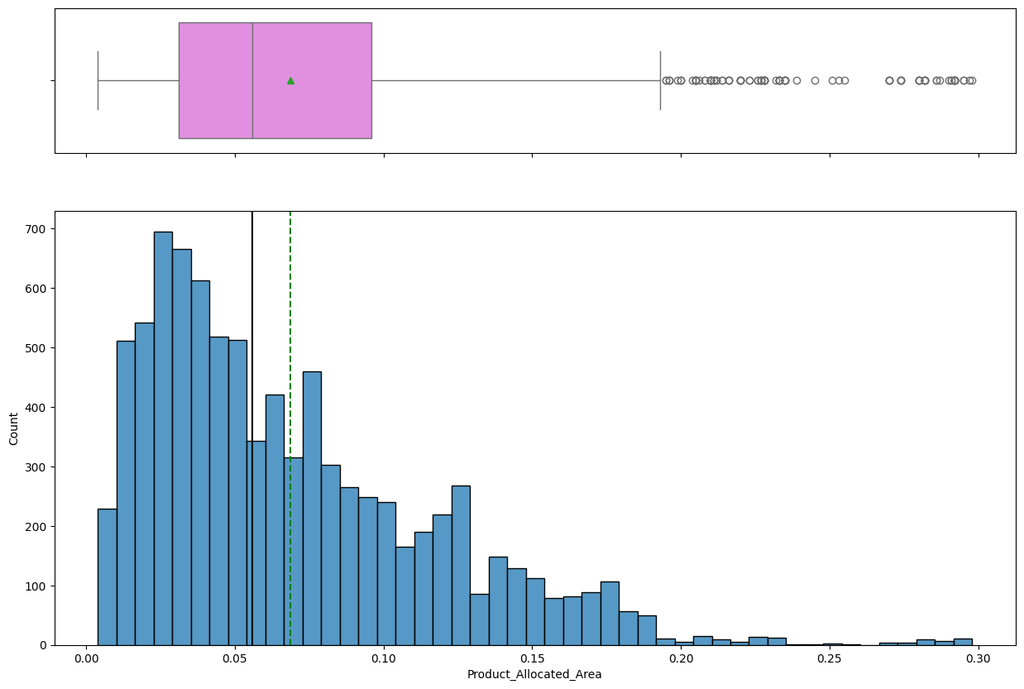

```python
histogram_boxplot(_data_copy, "Product_Allocated_Area")
```

### **Observations**

- This feature exhibits a right-skewed distribution, indicating that the highest concentration of products occupies a small allocated display area, ranging between 0 and 0.06. **As the allocated area increases, the number of products decreases.**
- A considerable number of products thus occupy a very small proportion of the total display area.
- Outlier values **do not appear to be concerning**; they are interpreted as naturally occurring due to the aforementioned skewness.

**4. Product_Type**

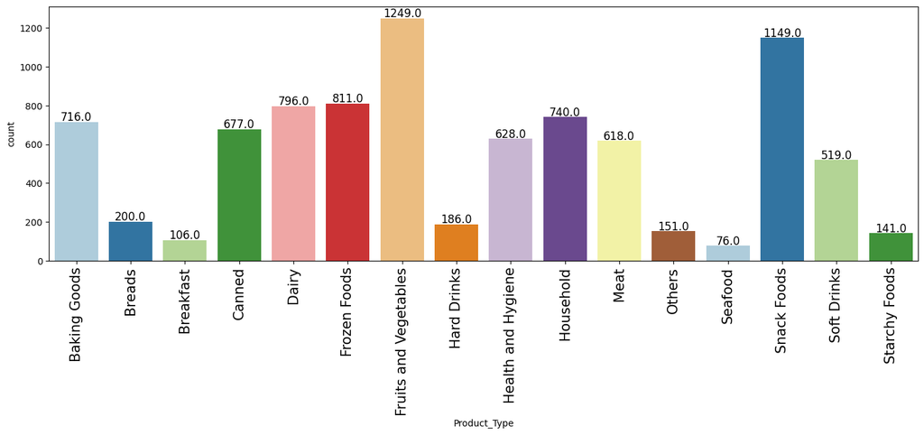

```python
labeled_barplot(_data_copy, "Product_Type")
```

```python
_percentage_types = _data_copy['Product_Type'].value_counts(normalize=True, sort=False)*100
_percentage_types.round(1)
```

| Product_Type | proportion |
| --- | --- |
| Baking Goods | 8.2 |
| Breads | 2.3 |
| Breakfast | 1.2 |
| Canned | 7.7 |
| Dairy | 9.1 |
| Frozen Foods | 9.3 |
| Fruits and Vegetables | 14.3 |
| Hard Drinks | 2.1 |
| Health and Hygiene | 7.2 |
| Household | 8.4 |
| Meat | 7.1 |
| Others | 1.7 |
| Seafood | 0.9 |
| Snack Foods | 13.1 |
| Soft Drinks | 5.9 |
| Starchy Foods | 1.6 |

**dtype:** float64

### **Observations**

- As previously observed, fruits and vegetables represent the dominant product category, accounting for **14.3%** of all products sold (1,249 items). This reinforces the store chain's commitment to offering products that promote customer well-being. However, snacks constitute the second-highest selling category, representing **13.1%** of products, and it is currently unknown whether these are healthy options.
- Other categories such as "Breads," "Breakfast," "Hard Drinks," "Seafood," and "Starchy Foods" each represent **less than 5%** of the total products sold.

**5. Product_MRP**

Maximum retail price of each product

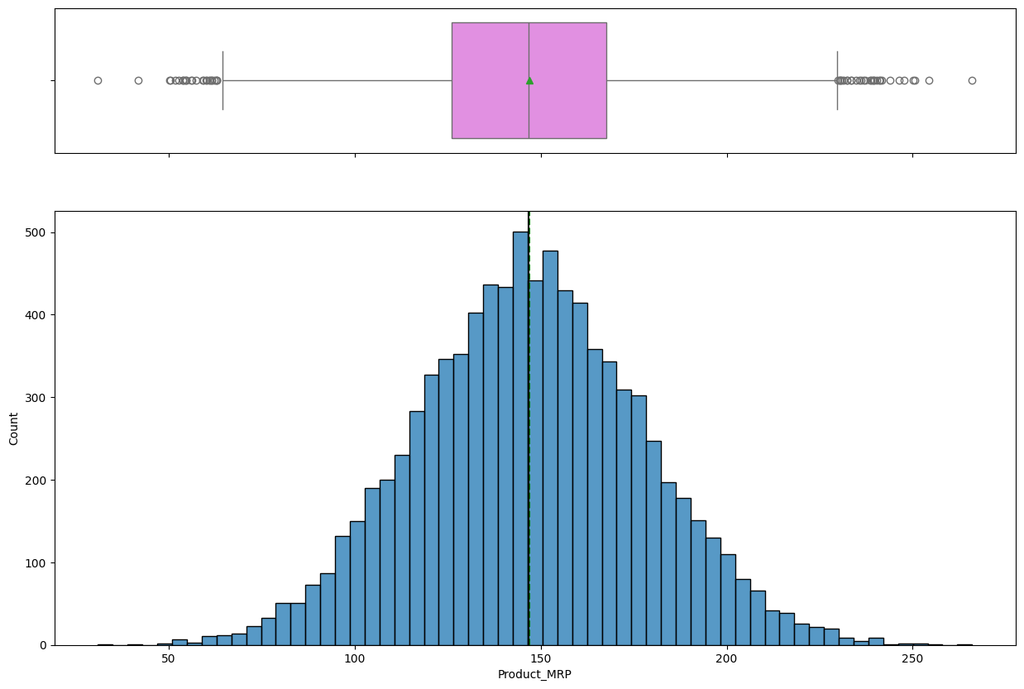

```python
histogram_boxplot(_data_copy, "Product_MRP")
```

### **Observations**

- The variable representing the maximum retail price of each product also exhibits a normal distribution. This is identifiable by its symmetrical bell shape, with data points clustered around a central value and decreasing in frequency as they move away from the center. The strongest concentration of prices is **observed around 145 USD - 150 USD**, which represents the most frequent price range.

**6. Store_Id**

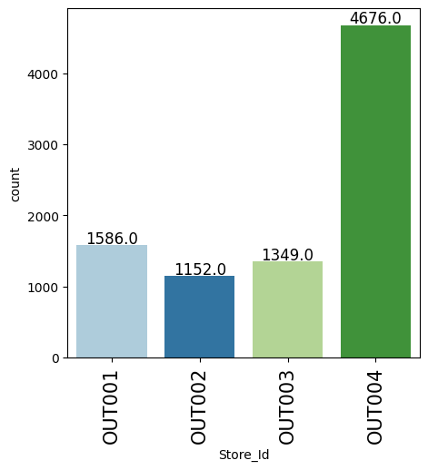

```python
labeled_barplot(_data_copy, "Store_Id")
```

```python
_percentage_types = _data_copy['Store_Id'].value_counts(normalize=True, sort=False)*100
_percentage_types.round(1)
```

| Store_Id | proportion |
| --- | --- |
| OUT004 | 53.4 |
| OUT003 | 15.4 |
| OUT001 | 18.1 |
| OUT002 | 13.1 |

**dtype:** float64

#### **Observations**

**7. Store_Establishment_Year**

Year in which the store was established

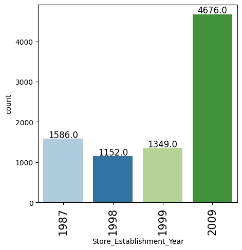

```python
labeled_barplot(_data_copy, "Store_Establishment_Year")
```

```python
_percentage_types = _data_copy['Store_Establishment_Year'].value_counts(normalize=True, sort=False)*100
_percentage_types.round(1)
```

| Store_Establishment_Year | proportion |
| --- | --- |
| 2009 | 53.4 |
| 1999 | 15.4 |
| 1987 | 18.1 |
| 1998 | 13.1 |

**dtype:** float64

### **Observations**

- More than 50% of the products in the dataset are sold in the store established in 2009, accounting for 4,676 products to be precise.

**8. Store_Size**

Size of the store depending on sq. feet

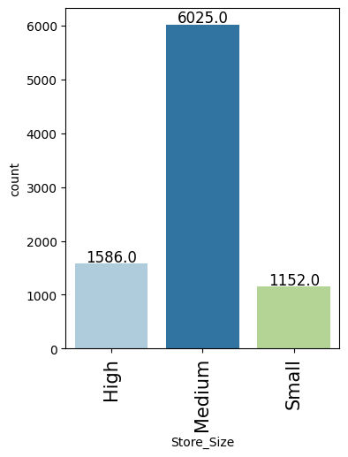

```python
labeled_barplot(_data_copy, "Store_Size")
```

```python
_percentage_types = _data_copy['Store_Size'].value_counts(normalize=True, sort=False)*100
_percentage_types.round(1)
```

| Store_Size | proportion |
| --- | --- |
| High | 18.1 |
| Medium | 68.8 |
| Small | 13.1 |

**dtype:** float64

### **Observations**

**9. Store_Location_City_Type**

Type of city in which the store is located

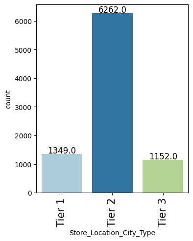

```python
labeled_barplot(_data_copy, "Store_Location_City_Type")
```

```python
_percentage_types = _data_copy['Store_Location_City_Type'].value_counts(normalize=True, sort=False)*100
_percentage_types.round(1)
```

| Store_Location_City_Type | proportion |
| --- | --- |
| Tier 1 | 15.4 |
| Tier 2 | 71.5 |
| Tier 3 | 13.1 |

**dtype:** float64

### **Observations**

**10. Store_Type**

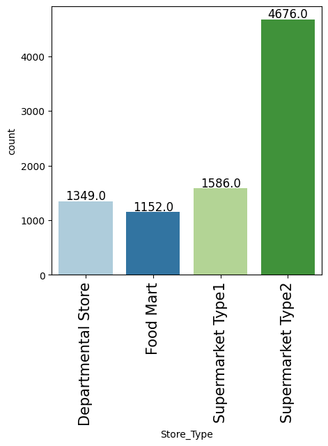

```python
labeled_barplot(_data_copy, "Store_Type")
```

```python
_percentage_types = _data_copy['Store_Type'].value_counts(normalize=True, sort=False)*100
_percentage_types.round(1)
```

| Store_Type | proportion |
| --- | --- |
| Departmental Store | 15.4 |
| Food Mart | 13.1 |
| Supermarket Type1 | 18.1 |
| Supermarket Type2 | 53.4 |

**dtype:** float64

## Bivariate Analysis

**Correlation**

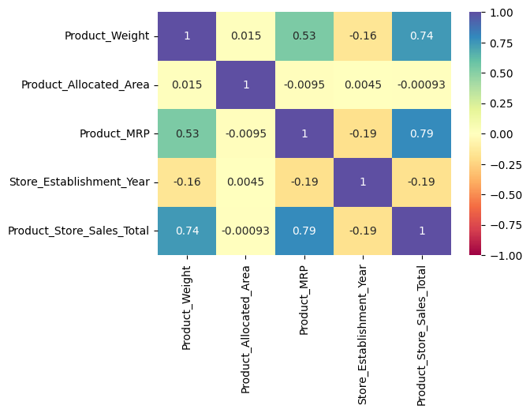

```python
import warnings
warnings.filterwarnings('ignore')
warnings.simplefilter('ignore')
plt.figure(figsize=(6,4))
sns.heatmap(_data_copy[_num_col].corr(),annot=True,cmap='Spectral',vmin=-1,vmax=1)
plt.show()
```

### **Observations**

- A positive correlation is observed between the maximum retail price and the weight of the product. This suggests that a heavier product tends to have a higher price.
- Product weight also correlates with total sales, which is logical given the established relationship between product price and weight.
- Similarly, and as anticipated, the product price exhibits a correlational effect on total sales.

**1. Product weight versus total product sales**

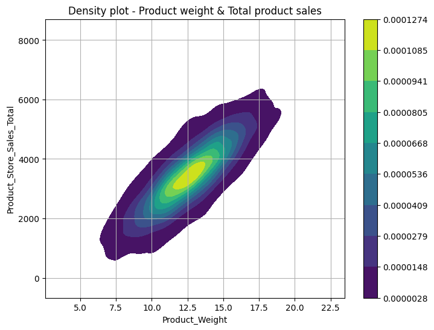

```python
plt.figure(figsize=(8, 6))
sns.kdeplot(x='Product_Weight', y='Product_Store_Sales_Total', data=_data_copy, fill=True, cmap='viridis', cbar=True)
plt.title('Density plot - Product weight & Total product sales')
plt.xlabel('Product_Weight')
plt.ylabel('Product_Store_Sales_Total')
plt.grid(True)
plt.show()
```

### **Observations**

- As noted previously, the graph also displays a positive correlation. This density plot not only indicates a relationship between the variables but also highlights where this relationship is strongest. Lighter colors at the center of the plot signify a higher density of data points, illustrating where the relationship between product weight and sales volume is most concentrated. For instance, **a considerable concentration of products is observed within an approximate weight range of 12 lb to 14 lb, generating sales between 3,500 USD and 4,000 USD**. These represent the most frequent characteristics within the dataset. This observation reinforces the statistical summary, which indicated that 50% of products weigh 12.66 lb and 75% do not exceed 14.18 lb. Similarly, the summary showed that the median product generates up to 3,452.34 USD, and 75% do not exceed 4,145.16 USD.
- Conversely, as the colors darken, the data density decreases, meaning there are fewer products with the weight and sales characteristics represented by each quadrant of the graph's grid

**2. Sugar content versus total product sales**

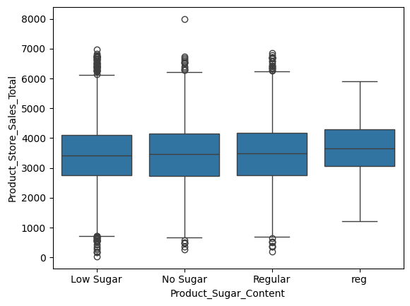

```python
sns.boxplot(x="Product_Sugar_Content", y="Product_Store_Sales_Total", data=_data_copy);
```

### **Observations**

- An interesting finding is that despite the majority of products sold being low in sugar, all sugar content categories generate very similar revenues. In other words, **the fact that over 50% of products are low in sugar does not translate to higher sales compared to products with a regular sugar level or sugar-free products**, at least when interpreting the median values.

**3. Allocated area versus total product sales**

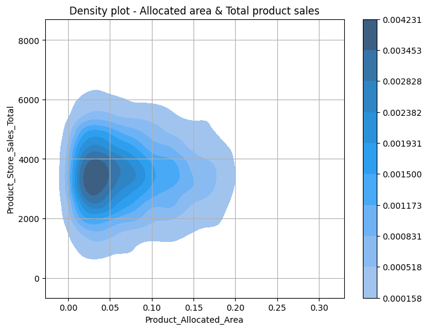

```python
plt.figure(figsize=(8, 6))
sns.kdeplot(x='Product_Allocated_Area', y='Product_Store_Sales_Total', data=_data_copy, fill=True, cbar=True)
plt.title('Density plot - Allocated area & Total product sales')
plt.xlabel('Product_Allocated_Area')
plt.ylabel('Product_Store_Sales_Total')
plt.grid(True)
plt.show()
```

### **Observations**

- There is no clear linear correlation observed between the product's allocated display area and its sales. The data points are dispersed without a distinct trend, indicating that a larger allocated area does not guarantee higher sales for a specific product, nor does a smaller area imply lower sales.
- Additionally, the majority of points are concentrated on the left side of the graph, specifically between 0.00 and approximately 0.18. This observation is consistent with the results from the histogram in the preceding section's univariable analysis.

**4. Product type versus total product sales**

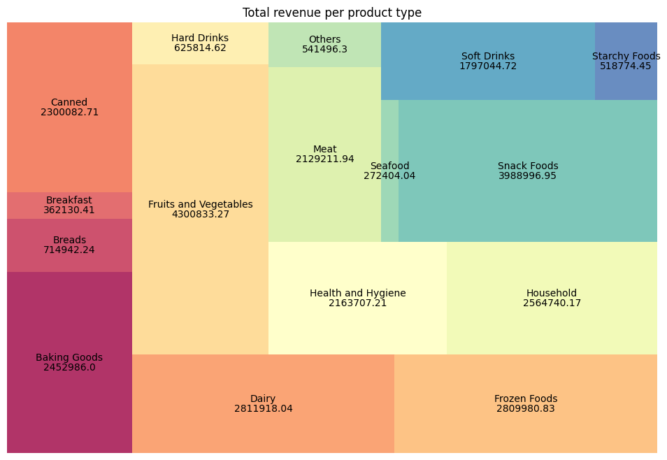

```python
# Group by product type and sum up the total sales
_revenue_x_type = _data_copy.groupby(["Product_Type"], as_index=False)["Product_Store_Sales_Total"].sum()

colors = [plt.cm.Spectral(i / float(len(_revenue_x_type['Product_Type']))) for i in range(len(_revenue_x_type['Product_Type']))]

plt.figure(figsize=[12, 8])
squarify.plot(sizes=_revenue_x_type['Product_Store_Sales_Total'],
              label=_revenue_x_type['Product_Type'],
              color=colors,
              alpha=.8,
              value=_revenue_x_type['Product_Store_Sales_Total'])
plt.title('Total revenue per product type')
plt.axis('off')
plt.show()
```

```python
_revenue_x_type.sort_values(by='Product_Store_Sales_Total', ascending=False)
```

|  | Product_Type | Product_Store_Sales_Total |
| --- | --- | --- |
| 6 | Fruits and Vegetables | 4300833.27 |
| 13 | Snack Foods | 3988996.95 |
| 4 | Dairy | 2811918.04 |
| 5 | Frozen Foods | 2809980.83 |
| 9 | Household | 2564740.17 |
| 0 | Baking Goods | 2452986.00 |
| 3 | Canned | 2300082.71 |
| 8 | Health and Hygiene | 2163707.21 |
| 10 | Meat | 2129211.94 |
| 14 | Soft Drinks | 1797044.72 |
| 1 | Breads | 714942.24 |
| 7 | Hard Drinks | 625814.62 |
| 11 | Others | 541496.30 |
| 15 | Starchy Foods | 518774.45 |
| 2 | Breakfast | 362130.41 |
| 12 | Seafood | 272404.04 |

#### **Observations**

- **The product type generating the highest sales is Fruits and Vegetables**, with a total of **4,300,833.27 USD**. This is followed by Snack Foods, which generated 3,988,996.95 USD, and Dairy, with 2,811,918.04 USD.

**5. Maximum retail price (MRP) of each product versus total product sales**

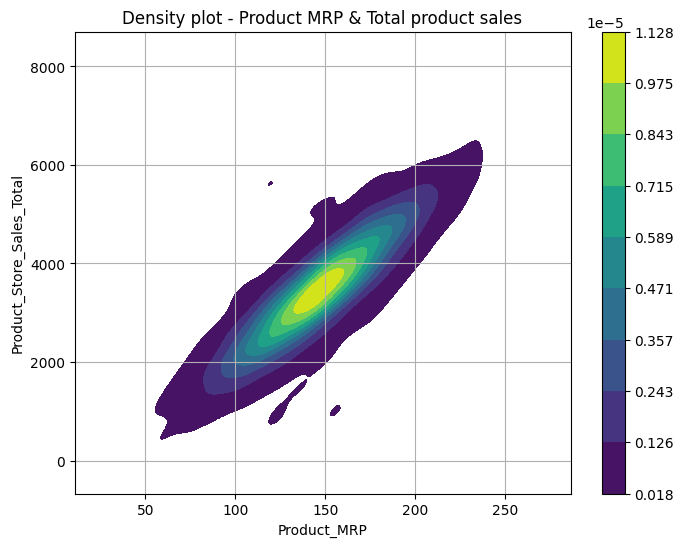

```python
plt.figure(figsize=(8, 6))
sns.kdeplot(x='Product_MRP', y='Product_Store_Sales_Total', data=_data_copy, fill=True, cmap='viridis', cbar=True)
plt.title('Density plot - Product MRP & Total product sales')
plt.xlabel('Product_MRP')
plt.ylabel('Product_Store_Sales_Total')
plt.grid(True)
plt.show()
```

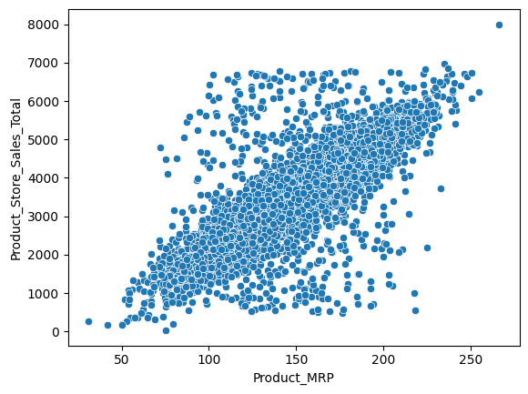

```python
sns.scatterplot(data=_data_copy, x='Product_MRP', y='Product_Store_Sales_Total')
plt.show()
```

### **Observations**

- The relationship between these variables exhibits a positive correlation. A significant concentration of products is observed within an approximate price range of 140 USD - 160 USD, generating sales between 3,000 USD and 4,000 USD. These figures represent the most frequent characteristics within the dataset.
- This observation reinforces the statistical summary, which indicated that 50% of products are priced at 146.74 USD, and 75% do not exceed 167.58 USD. Similarly, the summary showed that the median product generates up to 3,452.34 USD, with 75% not exceeding 4,145.16 USD.
- Conversely, darker colors indicate a decrease in data density, signifying fewer products with the maximum price and sales characteristics represented in those areas of the graph.

**6. Store ID versus total product sales**

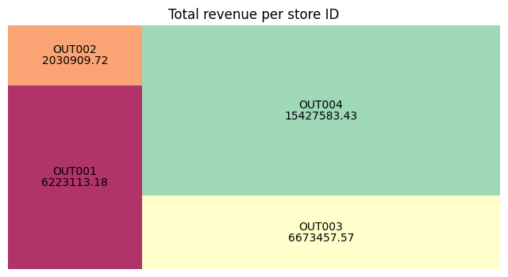

```python
# Group by Store_Id and sum up the total sales
_revenue_x_id = _data_copy.groupby(["Store_Id"], as_index=False)["Product_Store_Sales_Total"].sum()

colors = [plt.cm.Spectral(i / float(len(_revenue_x_id['Store_Id']))) for i in range(len(_revenue_x_id['Store_Id']))]

plt.figure(figsize=[8, 4])
squarify.plot(sizes=_revenue_x_id['Product_Store_Sales_Total'],
              label=_revenue_x_id['Store_Id'],
              color=colors,
              alpha=.8,
              value=_revenue_x_id['Product_Store_Sales_Total'])
plt.title('Total revenue per store ID')
plt.axis('off')
plt.show()
```

```python
_revenue_x_id.sort_values(by='Product_Store_Sales_Total', ascending=False)
```

|  | Store_Id | Product_Store_Sales_Total |
| --- | --- | --- |
| 3 | OUT004 | 15427583.43 |
| 2 | OUT003 | 6673457.57 |
| 0 | OUT001 | 6223113.18 |
| 1 | OUT002 | 2030909.72 |

### **Observations**

- The store with the highest total sales is OUT004, achieving 15,427,583.43 USD.
- It is confirmed that the store with the lowest total sales is OUT002, with only 2,030,909.72 USD.

**7. Store Establishment Year versus total product sales**

[figure not shown]

```python
# Group by Store_Establishment_Year and sum up the total sales
_revenue_x_year = _data_copy.groupby(["Store_Establishment_Year"], as_index=False)["Product_Store_Sales_Total"].sum()

colors = [plt.cm.Spectral(i / float(len(_revenue_x_type['Store_Establishment_Year']))) for i in range(len(_revenue_x_type['Store_Establishment_Year']))]

plt.figure(figsize=[8, 4])
squarify.plot(sizes=_revenue_x_type['Product_Store_Sales_Total'],
              label=_revenue_x_type['Store_Establishment_Year'],
              color=colors,
              alpha=.8,
              value=_revenue_x_type['Product_Store_Sales_Total'])
plt.title('Total revenue per store year of establishment')
plt.axis('off')
plt.show()
```

```python
_revenue_x_year.sort_values(by='Product_Store_Sales_Total', ascending=False)
```

|  | Store_Establishment_Year | Product_Store_Sales_Total |
| --- | --- | --- |
| 3 | 2009 | 15427583.43 |
| 2 | 1999 | 6673457.57 |
| 0 | 1987 | 6223113.18 |
| 1 | 1998 | 2030909.72 |

#### **Observations**

- **The store established in 2009 generates the highest total sales, amounting to 15,427,583.43 USD.**
- The store inaugurated in 1998, while not the oldest, has the lowest total sales per product, with a total of 2,030,909.72 USD.

**8. Store size Year versus total product sales**

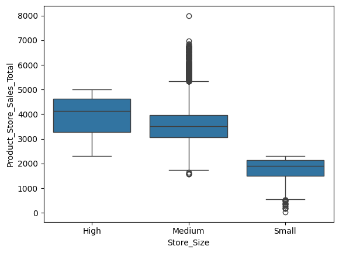

```python
sns.boxplot(x="Store_Size", y="Product_Store_Sales_Total", data=_data_copy);
```

```python
summary_stats = _data_copy.groupby('Store_Size')['Product_Store_Sales_Total'].agg(
    mean='mean',
    Q1=lambda x: x.quantile(0.25),
    median='median',
    Q3=lambda x: x.quantile(0.75),
    min='min',
    max='max'
).reset_index()

print(summary_stats)
```

```
  Store_Size         mean         Q1    median         Q3      min      max
0       High  3923.778802  3285.5100  4139.645  4639.4000  2300.56  4997.63
1     Medium  3668.222573  3060.3800  3511.100  3969.8100  1561.06  8000.00
2      Small  1762.942465  1495.4725  1889.495  2133.6225    33.00  2299.63
```

#### **Observations**

- As anticipated, store size significantly influences product sales. Larger stores tend to generate higher median sales than medium-sized and small-sized stores.
- Small stores consistently exhibit the lowest sales performance, likely due to factors such as a more limited inventory and reduced physical space.

**9. Store location versus total product sales**

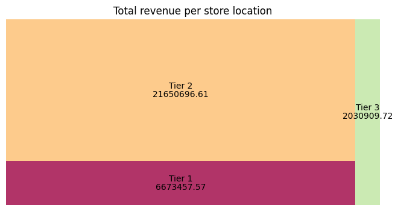

```python
# Group by Store_Location_City_Type and sum up the total sales
_revenue_x_location = _data_copy.groupby(["Store_Location_City_Type"], as_index=False)["Product_Store_Sales_Total"].sum()

colors = [plt.cm.Spectral(i / float(len(_revenue_x_location['Store_Location_City_Type']))) for i in range(len(_revenue_x_location['Store_Location_City_Type']))]

plt.figure(figsize=[8, 4])
squarify.plot(sizes=_revenue_x_location['Product_Store_Sales_Total'],
              label=_revenue_x_location['Store_Location_City_Type'],
              color=colors,
              alpha=.8,
              value=_revenue_x_location['Product_Store_Sales_Total'])
plt.title('Total revenue per store location')
plt.axis('off')
plt.show()
```

```python
_revenue_x_location.sort_values(by='Product_Store_Sales_Total', ascending=False)
```

|  | Store_Location_City_Type | Product_Store_Sales_Total |
| --- | --- | --- |
| 1 | Tier 2 | 21650696.61 |
| 0 | Tier 1 | 6673457.57 |
| 2 | Tier 3 | 2030909.72 |

#### **Observations**

- Tier 2 represents the location with the highest total sales per product, significantly surpassing both Tier 1 and Tier 3 locations.

**10. Store type versus total product sales**

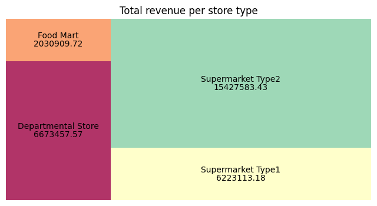

```python
# Group by Store_Type and sum up the total sales
_revenue_store_type = _data_copy.groupby(["Store_Type"], as_index=False)["Product_Store_Sales_Total"].sum()

colors = [plt.cm.Spectral(i / float(len(_revenue_store_type['Store_Type']))) for i in range(len(_revenue_store_type['Store_Type']))]

plt.figure(figsize=[8, 4])
squarify.plot(sizes=_revenue_store_type['Product_Store_Sales_Total'],
              label=_revenue_store_type['Store_Type'],
              color=colors,
              alpha=.8,
              value=_revenue_store_type['Product_Store_Sales_Total'])
plt.title('Total revenue per store type')
plt.axis('off')
plt.show()
```

```python
_revenue_store_type.sort_values(by='Product_Store_Sales_Total', ascending=False)
```

|  | Store_Type | Product_Store_Sales_Total |
| --- | --- | --- |
| 3 | Supermarket Type2 | 15427583.43 |
| 0 | Departmental Store | 6673457.57 |
| 2 | Supermarket Type1 | 6223113.18 |
| 1 | Food Mart | 2030909.72 |

#### **Observations**

- As previously observed, the "Supermarket Type2" store type accounts for the highest product sales, specifically totaling 15,427,583.43 USD.

**11. Store ID versus Store establishment year**

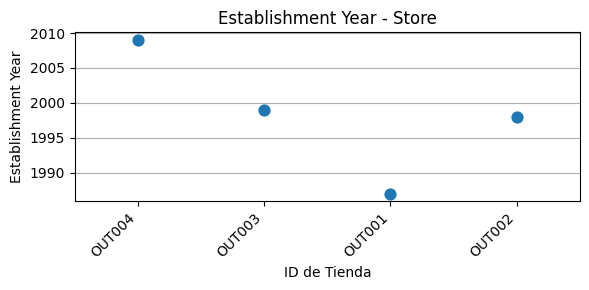

```python
plt.figure(figsize=(6, 3))
sns.pointplot(x='Store_Id', y='Store_Establishment_Year', data=_data_copy, join=False, ci=None, marker='o', linestyles='')
plt.xlabel('ID de Tienda')
plt.ylabel('Establishment Year')
plt.title('Establishment Year - Store')
plt.xticks(rotation=45, ha='right')
plt.grid(axis='y')
plt.tight_layout()
plt.show()
```

#### **Observations**

- The oldest store is OUT001, established in 1987. The newest store, inaugurated in 2009, is OUT004.

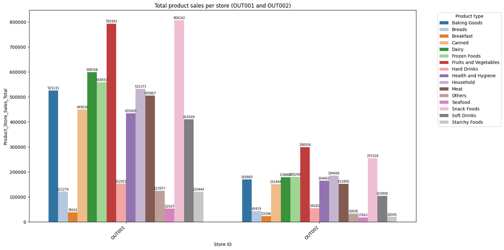

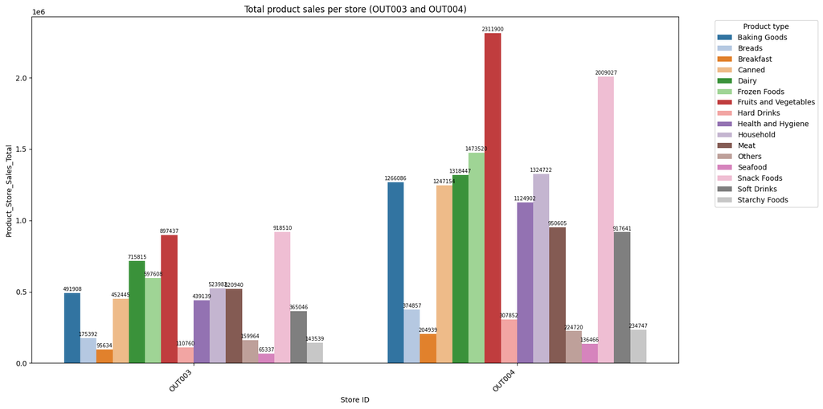

```python
revenue_by_store_product_type = _data_copy.groupby(['Store_Id', 'Product_Type'])['Product_Store_Sales_Total'].sum().reset_index()
stores_group1 = ['OUT001','OUT002']
stores_group2 = ['OUT003','OUT004']

df_group1 = revenue_by_store_product_type[revenue_by_store_product_type['Store_Id'].isin(stores_group1)]
df_group2 = revenue_by_store_product_type[revenue_by_store_product_type['Store_Id'].isin(stores_group2)]

# First plot
plt.figure(figsize=(16, 8))
ax1 = sns.barplot(
    data=df_group1, x='Store_Id', y='Product_Store_Sales_Total',hue='Product_Type',palette='tab20'
)
plt.title('Total product sales per store (OUT001 and OUT002)')
plt.xlabel('Store ID')
plt.ylabel('Product_Store_Sales_Total')
plt.xticks(rotation=45, ha='right')
plt.legend(title='Product type', bbox_to_anchor=(1.05, 1), loc='upper left')
plt.tight_layout()

for p in ax1.patches:
    height = p.get_height()
    if height > 50:
        ax1.annotate(f'{height:.0f}',
                     (p.get_x() + p.get_width() / 2., height),
                     ha='center', va='center',
                     xytext=(0, 5), textcoords='offset points',
                     fontsize=7, color='black')
plt.show()

# Second plot
plt.figure(figsize=(16, 8))
ax2 = sns.barplot(
    data=df_group2, x='Store_Id', y='Product_Store_Sales_Total',hue='Product_Type', palette='tab20'
)
plt.title('Total product sales per store (OUT003 and OUT004)')
plt.xlabel('Store ID')
plt.ylabel('Product_Store_Sales_Total')
plt.xticks(rotation=45, ha='right')
plt.legend(title='Product type', bbox_to_anchor=(1.05, 1), loc='upper left')
plt.tight_layout()

for p in ax2.patches:
    height = p.get_height()
    if height > 50:
        ax2.annotate(f'{height:.0f}',
                     (p.get_x() + p.get_width() / 2., height),
                     ha='center', va='center',
                     xytext=(0, 5), textcoords='offset points',
                     fontsize=7, color='black')
plt.show()
```

### **Observations**

- At Store ID **OUT001, the highest-selling product categories are "Fruits and Vegetables" and "Snack Foods", generating total sales of 792,993 USD and 806,142 USD respectively**. The lowest-selling category is "Breakfast," with total sales of 38,161 USD. The second-lowest selling category is "Seafood," with total sales of 52,937 USD.
- Similarly, for Store ID **OUT002, "Fruits and Vegetables" and "Snack Foods" are the predominant categories**. In this store, the least sold category is "Seafood," with sales totaling 17,663 USD.
- For both Store ID **OUT003 and OUT004, "Fruits and Vegetables" and "Snack Foods" also consistently emerge as the top-selling categories**. Notably, Store OUT004 records the highest sales within these categories, with 2,311,900 USD from "Fruits and Vegetables" and 2,009,027 USD from "Snack Foods." In both OUT003 and OUT004, "Seafood" consistently represents the lowest-selling category.

# **Data Preprocessing**

## **Feature engineering**

**Outlier check**

```python
Q1 = _data_copy.select_dtypes(include=["float64", "int64"]).quantile(0.25)
Q3 = _data_copy.select_dtypes(include=["float64", "int64"]).quantile(0.75)
# Inter Quantile Range
IQR = Q3 - Q1

lower = (Q1 - 1.5 * IQR) #Values outside these bounds are outliers
upper = (Q3 + 1.5 * IQR) #Values outside these bounds are outliers

((_data_copy.select_dtypes(include=["float64", "int64"]) < lower)|(_data_copy.select_dtypes(include=["float64", "int64"]) > upper)).sum() / len(_data_copy) * 100
```

|  | 0 |
| --- | --- |
| Product_Weight | 0.616227 |
| Product_Allocated_Area | 1.186808 |
| Product_MRP | 0.650462 |
| Store_Establishment_Year | 0.000000 |
| Product_Store_Sales_Total | 1.357982 |

**dtype:** float64

### **Observations**

- The outliers are not significant, and therefore, no action will be taken.

**Variable: Product_Sugar_Content. Unificar "reg" con "Regular"**

```python
_data_copy['Product_Sugar_Content'].replace(to_replace=["reg"], value=["Regular"], inplace=True)
```

```python
_data_copy['Product_Sugar_Content'].unique()
```

```
['Low Sugar', 'Regular', 'No Sugar']
Categories (3, object): ['Low Sugar', 'No Sugar', 'Regular']
```

**Combine variables to capture nonlinear or proportional relationships**

```python
_data_copy['_price_per_Gram'] = _data_copy['Product_MRP'] / _data_copy['Product_Weight']
_data_copy['_weight_per_area'] = _data_copy['Product_Weight'] / _data_copy['Product_Allocated_Area']
```

### **Observations**

- The objective of creating new variables through their combination is to enable the model to learn non-linear relationships, thereby facilitating the identification of implicit patterns.

**Context proxies**

```python
_avg_sales = _data_copy.groupby("Store_Id")["Product_Store_Sales_Total"].mean().reset_index()
_avg_sales.rename(columns={"Product_Store_Sales_Total": "_avg_sales_x_store"}, inplace=True)
_data_copy = _data_copy.merge(_avg_sales, on="Store_Id", how="left")
```

### **Observations**

- The objective is to utilize a derived variable to indirectly represent its associated variable. For example, calculating the average sales per store could indirectly reflect each location's capacity to generate profit, encompassing both the store itself and its surrounding area (e.g., the socio-economic status of the surrounding area)).

**Drop unnecessary column**

```python
_data_copy.drop(['Product_Id','Store_Id','Store_Establishment_Year'], axis=1, inplace=True)
```

```python
_data_copy.head()
```

|  | Product_Weight | Product_Sugar_Content | Product_Allocated_Area | Product_Type | Product_MRP | Store_Size | Store_Location_City_Type | Store_Type | Product_Store_Sales_Total | _price_per_Gram | _weight_per_area | _avg_sales_x_store |
| --- | --- | --- | --- | --- | --- | --- | --- | --- | --- | --- | --- | --- |
| 0 | 12.66 | Low Sugar | 0.027 | Frozen Foods | 117.08 | Medium | Tier 2 | Supermarket Type2 | 2842.40 | 9.248025 | 468.888889 | 3299.312111 |
| 1 | 16.54 | Low Sugar | 0.144 | Dairy | 171.43 | Medium | Tier 1 | Departmental Store | 4830.02 | 10.364571 | 114.861111 | 4946.966323 |
| 2 | 14.28 | Regular | 0.031 | Canned | 162.08 | High | Tier 2 | Supermarket Type1 | 4130.16 | 11.350140 | 460.645161 | 3923.778802 |
| 3 | 12.10 | Low Sugar | 0.112 | Baking Goods | 186.31 | High | Tier 2 | Supermarket Type1 | 4132.18 | 15.397521 | 108.035714 | 3923.778802 |
| 4 | 9.57 | No Sugar | 0.010 | Health and Hygiene | 123.67 | Small | Tier 3 | Food Mart | 2279.36 | 12.922675 | 957.000000 | 1762.942465 |

**Preprocessing pipeline for encoding categorical features**

```python
_categorical_transformer = OneHotEncoder(handle_unknown='ignore')

_pipeline_preprocessor = ColumnTransformer(
    transformers=[
        ('cat', _categorical_transformer, _cat)
    ]
)
```

### **Additional observations on feature engineering**

- Imputation is not necessary as there are no missing values in the dataset.
- The models to be implemented: Random Forest and Gradient Boosting, do not require data scaling.
- With "Product_MRP" and "Product_Store_Sales_Total" displaying normal (symmetrical) distributions, additional transformations to mitigate bias or extreme outliers are unnecessary.
- Overall, the dataset is clean and well-organized, thus extensive feature engineering tasks are not required.

**Data splitting**

```python
X = _data_copy.drop(["Product_Store_Sales_Total"], axis=1)
y = _data_copy["Product_Store_Sales_Total"]
```

```python
# Splitting data into training, validation and test set:
X_temp, X_test, y_temp, y_test = train_test_split(
    X, y, test_size=0.2, random_state=1
)

# Split the temporary set into train and validation
X_train, X_val, y_train, y_val = train_test_split(
    X_temp, y_temp, test_size=0.25, random_state=1
)
print(X_train.shape, X_val.shape, X_test.shape)
```

```
(5257, 11) (1753, 11) (1753, 11)
```

```python
print("Shape of training: ", X_train.shape)
print("Shape of validation: ", X_val.shape)
print("Shape of test: ", X_test.shape)
```

```
Shape of training:  (5257, 11)
Shape of validation:  (1753, 11)
Shape of test:  (1753, 11)
```

# **Model Building**

### **Metric**

- **Problem Type and Objective**
- The problem type is regression, with the objective of forecasting the Product_Store_Sales_Total variable. The aim is to quantify the difference between the values generated by the model and the actual sales figures.
- **Key Metric: RMSE**: the primary metric of focus will be RMSE (Root Mean Squared Error). This metric is chosen to penalize errors with larger deviations, thereby mitigating errors that could significantly impact the prediction of high-profit products. In other words, not all sales contribute equally to business value.
- Outliers are unlikely to significantly affect the RMSE.
- RMSE will indicate the average magnitude of difference between the predictions and the actual values.
- **Complementary Metric**: R-Squared Additionally, R-Squared (coefficient of determination) will be used to identify the percentage of sales variation explained by the implemented models.

## **Models: Random Forest Regressor and Gradient Boosting Regressor**

### **Tasks**

- **Fit**: training and validation
  - **Pipeline**: make_pipeline (Preprocessing pipeline for encoding categorical features, model), then fit.
- **Predict**: pipeline, x_train. y_train
- **Compute metrics**: r2 score, adjr2, RMSE, MAE, MAPE.

```python
_models.append(("Random Forest Regressor - Before tuning", RandomForestRegressor(random_state=1)))
_models.append(("Gradient Boost Regressor - Before tuning", GradientBoostingRegressor(random_state=1)))
```

**Performance - Training**

```python
_perf_train
```

|  | RMSE | MAE | R-squared | Adj. R-squared | MAPE | Model |
| --- | --- | --- | --- | --- | --- | --- |
| 0 | 599.302247 | 471.734564 | 0.683112 | 0.682447 | 0.166443 | Random Forest Regressor - Before tuning |
| 1 | 602.784108 | 474.329441 | 0.679419 | 0.678747 | 0.167860 | Gradient Boost Regressor - Before tuning |

**Performance - Validation**

```python
_perf_val
```

|  | RMSE | MAE | R-squared | Adj. R-squared | MAPE | Model |
| --- | --- | --- | --- | --- | --- | --- |
| 0 | 589.020035 | 459.391759 | 0.690892 | 0.688939 | 0.188043 | Random Forest Regressor - Before tuning |
| 1 | 576.429627 | 451.981812 | 0.703966 | 0.702095 | 0.186927 | Gradient Boost Regressor - Before tuning |

### **Observations**

**RMSE (Root Mean Squared Error)**: This metric quantifies the average magnitude by which predictions deviate from actual values.

- While the difference between the two models isn't substantial, the Gradient Boost model demonstrates a lower RMSE of 576.43 on the validation set, compared to Random Forest's 589.02. Consequently, Gradient Boost exhibits superior predictive accuracy on unseen data
- There's no concern regarding overfitting.

**R-Squared**: This metric represents the proportion of variability accounted for by the model.

- The R-Squared value on the validation set is also marginally superior for the Gradient Boost model (0.70 versus 0.69); still, both models do an acceptable job of explaining the data's variability.

# **Model Performance Improvement - Hyperparameter Tuning**

**Random forest**

### **Hyperparameters to consider**

- **n_estimators**: [50, 100, 150, 200],
- **max_depth**: [10, 15, 20, None],
- **min_samples_leaf**: [10, 15, 25, 30],
- **max_features**: ['sqrt', 'log2'],
- **max_samples**: [0.3, 0.5, 0.7, 0.9],
- **criterion**: ['squared_error']
- **RandomizedSearchCV**:
  - estimator=_pipeline
  - Hyperparameters
  - jobs = -1
  - iterations = 60
  - scoring = neg_root_mean_squared_error
  - cv = 5
  - random state = 1

```python
_tuned_RF = RandomForestRegressor(random_state=1)
_pipeline_RF = make_pipeline(_pipeline_preprocessor, _tuned_RF)

print("Best params:", _rf_randomized_cv.best_params_)
print("Best CV RMSE:", -_rf_randomized_cv.best_score_)
```

```
Best params: {'randomforestregressor__n_estimators': 100, 'randomforestregressor__min_samples_leaf': 30, 'randomforestregressor__max_samples': 0.9, 'randomforestregressor__max_features': 'sqrt', 'randomforestregressor__max_depth': 15, 'randomforestregressor__criterion': 'squared_error'}
Best CV RMSE: 609.5711902921707
```

```python
best_pipeline_rf = _rf_randomized_cv.best_estimator_
best_pipeline_rf
```

```
Pipeline(steps=[('columntransformer',
                 ColumnTransformer(transformers=[('cat',
                                                  OneHotEncoder(handle_unknown='ignore'),
                                                  ['Product_Sugar_Content',
                                                   'Product_Type', 'Store_Size',
                                                   'Store_Location_City_Type',
                                                   'Store_Type'])])),
                ('randomforestregressor',
                 RandomForestRegressor(max_depth=15, max_features='sqrt',
                                       max_samples=0.9, min_samples_leaf=30,
                                       random_state=1))])
```

```python
_predictions_train_rf = model_performance_regression(best_pipeline_rf, X_train, y_train)
_predictions_train_rf["Model"] = 'Random Forest Regressor - After tuning'
_perf_train = pd.concat([_perf_train,_predictions_train_rf], ignore_index=True)

_predictions_train_rf
```

|  | RMSE | MAE | R-squared | Adj. R-squared | MAPE | Model |
| --- | --- | --- | --- | --- | --- | --- |
| 0 | 605.067619 | 476.487114 | 0.676986 | 0.676308 | 0.169244 | Random Forest Regressor - After tuning |

```python
_predictions_val_rf = model_performance_regression(best_pipeline_rf, X_val, y_val)
_predictions_val_rf["Model"] = 'Random Forest Regressor - After tuning'
_perf_val = pd.concat([_perf_val,_predictions_val_rf], ignore_index=True)

_predictions_val_rf
```

|  | RMSE | MAE | R-squared | Adj. R-squared | MAPE | Model |
| --- | --- | --- | --- | --- | --- | --- |
| 0 | 573.516807 | 450.611094 | 0.70695 | 0.705098 | 0.184908 | Random Forest Regressor - After tuning |

**Gradient boosting**

### **Hyperparameters to consider**

- **n_estimators**: [100, 150, 200, 250],
- **learning_rate**: [0.01, 0.05, 0.1],
- **subsample**: [0.5, 0.6, 0.7, 0.8, 1],
- **max_features**: ['sqrt', 'log2', None],
- **max_depth**: [3, 5, 8, 10,],
- **min_samples_split**: [6, 8, 10, 12]
- **min_samples_leaf:**[4, 8,10]
- **RandomizedSearchCV**:
  - estimator=_pipeline
  - Hyperparameters
  - jobs = -1
  - iterations = 60
  - scoring = neg_root_mean_squared_error
  - cv = 5
  - random state = 1

```python
_tuned_GB = GradientBoostingRegressor(random_state=1)
_pipeline = make_pipeline(_pipeline_preprocessor, _tuned_GB)

# Best Hyperparameters scores (positive RMSE)
print("Best params:", _GB_randomized_cv.best_params_)
print("Best CV RMSE:", -_GB_randomized_cv.best_score_)
```

```
Best params: {'gradientboostingregressor__subsample': 0.7, 'gradientboostingregressor__n_estimators': 100, 'gradientboostingregressor__min_samples_split': 6, 'gradientboostingregressor__min_samples_leaf': 8, 'gradientboostingregressor__max_features': 'sqrt', 'gradientboostingregressor__max_depth': 3…
Best CV RMSE: 610.1829332102039
```

```python
best_pipeline_gb = _GB_randomized_cv.best_estimator_
best_pipeline_gb
```

```
Pipeline(steps=[('columntransformer',
                 ColumnTransformer(transformers=[('cat',
                                                  OneHotEncoder(handle_unknown='ignore'),
                                                  ['Product_Sugar_Content',
                                                   'Product_Type', 'Store_Size',
                                                   'Store_Location_City_Type',
                                                   'Store_Type'])])),
                ('gradientboostingregressor',
                 GradientBoostingRegressor(learning_rate=0.05,
                                           max_features='sqrt',
                                           min_samples_leaf=8,
                                           min_samples_split=6, random_state=1,
                                           subsample=0.7))])
```

```python
_predictions_train_gb = model_performance_regression(best_pipeline_gb, X_train, y_train)
_predictions_train_gb["Model"] = 'Gradient boost - After tuning'
_perf_train = pd.concat([_perf_train,_predictions_train_gb], ignore_index=True)

_predictions_train_gb
```

|  | RMSE | MAE | R-squared | Adj. R-squared | MAPE | Model |
| --- | --- | --- | --- | --- | --- | --- |
| 0 | 604.465527 | 476.781998 | 0.677628 | 0.676952 | 0.169115 | Gradient boost - After tuning |

```python
_predictions_val_gb = model_performance_regression(best_pipeline_gb, X_val, y_val)
_predictions_val_gb["Model"] = 'Gradient boost - After tuning'
_perf_val = pd.concat([_perf_val,_predictions_val_gb], ignore_index=True)

_predictions_val_gb
```

|  | RMSE | MAE | R-squared | Adj. R-squared | MAPE | Model |
| --- | --- | --- | --- | --- | --- | --- |
| 0 | 573.8879 | 451.414201 | 0.706571 | 0.704717 | 0.186055 | Gradient boost - After tuning |

### **Observations**

After hyperparameter tuning,an improvement in the RMSE was observed on the validation set. Specifically, the Random Forest model's RMSE decreased from 589.02 to 573.5, while the Gradient Boost model's RMSE improved from 576.43 to 573.89.

Although the difference is marginal, the enhancement resulting from the tuning process is evident.

# **Model Performance Comparison, Final Model Selection, and Serialization**

### **Performance comparison - Training**

```python
_perf_train
```

|  | RMSE | MAE | R-squared | Adj. R-squared | MAPE | Model |
| --- | --- | --- | --- | --- | --- | --- |
| 0 | 599.302247 | 471.734564 | 0.683112 | 0.682447 | 0.166443 | Random Forest Regressor - Before tuning |
| 1 | 602.784108 | 474.329441 | 0.679419 | 0.678747 | 0.167860 | Gradient Boost Regressor - Before tuning |
| 2 | 605.067619 | 476.487114 | 0.676986 | 0.676308 | 0.169244 | Random Forest Regressor - After tuning |
| 3 | 604.465527 | 476.781998 | 0.677628 | 0.676952 | 0.169115 | Gradient boost - After tuning |

### **Observations**

**Training set**

- For the Random Forest model, a slight deterioration in the RMSE was observed, increasing from 599.30 to 605. A similar trend was noted for the R-Squared value.
- The Gradient Boost model also exhibited a deterioration in its RMSE, rising from 602.78 to 604.46.
- However, in both instances, the difference is not substantial. The values obtained from the validation set will be reviewed, as they are of greater interest for assessing whether an improvement in the models' generalization capabilities for predicting unseen data has occurred.

### **Performance comparison - Validation**

```python
_perf_val
```

|  | RMSE | MAE | R-squared | Adj. R-squared | MAPE | Model |
| --- | --- | --- | --- | --- | --- | --- |
| 0 | 589.020035 | 459.391759 | 0.690892 | 0.688939 | 0.188043 | Random Forest Regressor - Before tuning |
| 1 | 576.429627 | 451.981812 | 0.703966 | 0.702095 | 0.186927 | Gradient Boost Regressor - Before tuning |
| 2 | 573.516807 | 450.611094 | 0.706950 | 0.705098 | 0.184908 | Random Forest Regressor - After tuning |
| 3 | 573.887900 | 451.414201 | 0.706571 | 0.704717 | 0.186055 | Gradient boost - After tuning |

### **Observations**

**Validation set**

### **Final model selection**

- Both models yielded very similar results. However, the Random Forest model was selected after applying hyperparameter tuning due to its superior RMSE value of 573.52 on the validation set, and its better R-Squared metric of 0.71.
- Additionally, Random Forest models offer greater interpretability compared to Gradient Boost models, and their training time is shorter.

### **Performance check on the test set**

```python
_predictions_test = model_performance_regression(best_pipeline_rf, X_test, y_test)
_predictions_test
```

|  | RMSE | MAE | R-squared | Adj. R-squared | MAPE |
| --- | --- | --- | --- | --- | --- |
| 0 | 621.011706 | 489.714707 | 0.66544 | 0.663326 | 0.166553 |

#### **Observations**

- RMSE and MAE: Given that the statistical summary indicates the third quartile (Q3) is USD 4,145.16, the RMSE and MAE errors represent a small fraction of the variable's value. This suggests the model demonstrates relatively good performance.
- R-Squared: The model explains 66.5% of the variability in the product's total sales across stores, which can be considered acceptable.
- MAPE: The model's average error is 16.65% of the actual value, which is also an acceptable figure.
- **Conclusion:** the selected model possesses the capability to predict product sales per store with an average error of 16.6%, explaining 66.5% of sales variability. Nevertheless, this capability could be enhanced through more detailed analysis and by evaluating alternative models or further fine-tuning hyperparameters.

### **Tasks**

- Define the file path to serialize the trained model along with the data preprocessing steps
- Save the trained model pipeline using joblib
  - .dump (best model pipeline, saved model path
- Load the saved model pipeline from the file
  - joblib.load

**Saved model check**

```python
saved_model
```

```
Pipeline(steps=[('columntransformer',
                 ColumnTransformer(transformers=[('cat',
                                                  OneHotEncoder(handle_unknown='ignore'),
                                                  ['Product_Sugar_Content',
                                                   'Product_Type', 'Store_Size',
                                                   'Store_Location_City_Type',
                                                   'Store_Type'])])),
                ('randomforestregressor',
                 RandomForestRegressor(max_depth=15, max_features='sqrt',
                                       max_samples=0.9, min_samples_leaf=30,
                                       random_state=1))])
```

**Testing predictions on the test set using the serialized/saved model**

```python
saved_model.predict(X_test)
```

```
array([3272.21098797, 4893.73359389, 4885.75254721, ..., 4881.93593986,
       3286.629245  , 3307.20963861])
```

# **Deployment - Backend**

## Flask Web Framework

### **Tasks**

- Store backend server deployment files
- %%writefile backend_files/app.py
- Initialize Flask app with a name
- Load the trained prediction model
- joblib.load("SuperKart_Model_Deployment.joblib")
- Define a route for the home page @_superkart_api.get('/')
- Define an endpoint @_superkart_api.post('/v1/forecast')
- Get JSON data from the request
- Extract features from the input data

```python
 _input = {
        'Product_Id': _data['Product_Id'],
        'Product_Weight': _data['Product_Weight'],
        'Product_Sugar_Content': _data['Product_Sugar_Content'],
        'Product_Allocated_Area': _data['Product_Allocated_Area'],
        'Product_Type': _data['Product_Type'],
        'Product_MRP': _data['Product_MRP'],
        'Store_Id': _data['Store_Id'],
        'Store_Establishment_Year': _data['Store_Establishment_Year'],
        'Store_Size': _data['Store_Size'],
        'Store_Location_City_Type': _data['Store_Location_City_Type'],
        'Store_Type': _data['Store_Type']
        }

    # Convert the extracted data into a DataFrame
    input_data = pd.DataFrame([_input])

    # Make a prediction using the trained model
    prediction = saved_model.predict(input_data).tolist()[0]

    # Return the prediction as a JSON response
    return jsonify({'Sales forescast': prediction})

# Run the Flask app in debug mode
if __name__ == '__main__':
    _superkart_api.run(debug=True)
```

```
Overwriting backend_files/app.py
```

## Dependencies File

```python
%%writefile backend_files/requirements.txt
numpy==2.0.2
pandas==2.2.2
scikit-learn==1.6.1
joblib==1.4.2
xgboost==2.1.4
requests==2.32.3
Werkzeug==2.2.2
flask==2.2.2
gunicorn==20.1.0
uvicorn[standard]
streamlit==1.43.2
```

```
Overwriting backend_files/requirements.txt
```

## Dockerfile

```python
%%writefile backend_files/Dockerfile
# Use a minimal base image with Python 3.9 installed
FROM python:3.9-slim

# Set the working directory inside the container to /app
WORKDIR /app

# Copy all files from the current directory on the host to the container's /app directory
COPY . .

# Install Python dependencies listed in requirements.txt
RUN pip3 install --no-cache-dir --upgrade -r requirements.txt

# Define the command to start the application using Gunicorn with 4 worker processes
# - `-w 4`: Uses 4 worker processes for handling requests
# - `-b 0.0.0.0:7860`: Binds the server to port 7860 on all network interfaces
# - `app:app`: Runs the Flask app (assuming `app.py` contains the Flask instance named `app`)
CMD ["gunicorn", "-w", "4", "-b", "0.0.0.0:7860", "app:_superkart_api"]
```

```
Overwriting backend_files/Dockerfile
```

## Setting up a Hugging Face Docker Space for the Backend

- The space was created via the Hugging Face website: https://huggingface.co/
- Repository id = JosueQB12/SuperKart_JQB
- Link of the Hugging Face space = https://huggingface.co/spaces/JosueQB12/superkart
- Base link for specifying endpoints = https://josueqb12-superkart.hf.space/

## Uploading Files to Hugging Face Space (Docker Space)

### **Tasks**

- Create access token
- Get repo id (Hugging Face space ID)
- Login to Hugging Face platform with the access token
- Initialize the API
- Upload Streamlit app files stored in the folder called deployment_files
  - api.upload_folder(folder_path (Local folder path), repo_id, repo_type="space")

```
CommitInfo(commit_url='https://huggingface.co/spaces/JosueQB12/superkart/commit/39fcb5d1ee278f67be5d97c535fa40ef17df0594', commit_message='Upload folder using huggingface_hub', commit_description='', oid='39fcb5d1ee278f67be5d97c535fa40ef17df0594', pr_url=None, repo_url=RepoUrl('https://huggingface.c…
```

### **Share the link of the Hugging Face space - Backend**

- https://huggingface.co/spaces/JosueQB12/superkart
- Base link for specifying endpoints = https://josueqb12-superkart.hf.space/

# **Deployment - Frontend**

## Streamlit for Interactive UI

### **Tasks**

- Create a folder for storing the files needed for frontend UI deployment.
- %%writefile frontend_files/app.py
- os.environ["STREAMLIT_HOME"] = "/tmp/.streamlit"
- os.environ["XDG_CONFIG_HOME"] = "/tmp"
- os.makedirs("/tmp/.streamlit", exist_ok=True)

```python
# Input fields
Product_Id = st.text_input("Product Id.", max_chars=10, help="Enter the product Id.")
Product_Weight = st.number_input("Product Weight", min_value=0.0, help="Enter the product weight (lbs).")
Product_Sugar_Content = st.selectbox("Product sugar content", ["Low Sugar", "Regular", "No Sugar"], help="Enter the product sugar content.")
Product_Allocated_Area = st.number_input("Product allocated area", min_value=0.0, help="Enter the ratio of the allocated display area of the product.")
Product_Type = st.selectbox("Product type", ["Baking Goods","Breads","Breakfast","Canned","Dairy","Frozen Foods","Fruits and Vegetables","Hard Drinks",
                                             "Health and Hygiene","Household","Meat","Others","Seafood","Snack Foods","Soft Drinks","Starchy Foods"],
                            help="Enter the product sugar content.")
Product_MRP = st.number_input("Product MRP", min_value=0.0, help="Enter the maximum retail price of the product.")
Store_Id = st.text_input("Store Id.", max_chars=10, help="Enter the store Id.")
Store_Establishment_Year = st.number_input("Store establishment year", min_value=1987, max_value=2025, help="Enter the year in which the store was established.")
Store_Size = st.selectbox("Store size", ["High", "Medium", "Small"], help="Enter the size of the store.")
Store_Location_City_Type = st.selectbox("Store size", ["Tier 1", "Tier 2", "Tier 3"], help="Enter the type of city in which the store is located.")
Store_Type = st.selectbox("Store type", ["Departmental Store", "Food Mart","Store_Type","Supermarket Type1","Supermarket Type2"],
                          help="Enter the type of store depending on the products that are being sold.")

product_data = {
    "Product_Id": Product_Id,
    "Product_Weight": Product_Weight,
    "Product_Sugar_Content": Product_Sugar_Content,
    "Product_Allocated_Area": Product_Allocated_Area,
    "Product_Type": Product_Type,
    "Product_MRP": Product_MRP,
    "Store_Id": Store_Id,
    "Store_Establishment_Year": Store_Establishment_Year,
    "Store_Size": Store_Size,
    "Store_Location_City_Type": Store_Location_City_Type,
    "Store_Type": Store_Type
}

if st.button("Predict", type='primary'):
    response = requests.post("https://josueqb12-superkart.hf.space/v1/forecast", json=product_data)
    if response.status_code == 200:
        result = response.json()
        _sales_forecast = result["Sales forescast"]
        st.write(f"Based on the information provided, the total predicted product store sales are: {_sales_forecast:.2f}.")
    else:
        st.error("Error in API request")
```

```
Overwriting frontend_files/app.py
```

## Dependencies File

```python
%%writefile frontend_files/requirements.txt
pandas==2.2.2
requests==2.32.3
streamlit==1.45.0
```

```
Overwriting frontend_files/requirements.txt
```

## DockerFile

```python
%%writefile frontend_files/Dockerfile
# Use a minimal base image with Python 3.9 installed
FROM python:3.9-slim

# Set the working directory inside the container to /app
WORKDIR /app

# Copy all files from the current directory on the host to the container's /app directory
COPY . .

# Install Python dependencies listed in requirements.txt
RUN pip3 install -r requirements.txt

# Define the command to run the Streamlit app on port 8501 and make it accessible externally
CMD ["streamlit", "run", "app.py", "--server.port=8501", "--server.address=0.0.0.0", "--server.enableXsrfProtection=false"]

# NOTE: Disable XSRF protection for easier external access in order to make batch predictions
```

```
Overwriting frontend_files/Dockerfile
```

## Uploading Files to Hugging Face Space (Streamlit Space)

### **Tasks**

- Set access token: Hugging Face token created from access keys in write mode
- Set repo id: Hugging Face space id
- Login to Hugging Face platform with the access token
- Initialize the API
- Upload Streamlit app files stored in the folder called deployment_files
  - api.upload_folder( folder_path: Local folder path, repo_id, repo_type)

```
CommitInfo(commit_url='https://huggingface.co/spaces/JosueQB12/superkart_frontend/commit/d6d162f0d45f545aac1cf2fc4790fe7e31497718', commit_message='Upload folder using huggingface_hub', commit_description='', oid='d6d162f0d45f545aac1cf2fc4790fe7e31497718', pr_url=None, repo_url=RepoUrl('https://hugg…
```

### **Share the link of the Hugging Face space - Frontend**

- https://huggingface.co/spaces/JosueQB12/superkart_frontend

**Test**

```python
_url = "https://josueqb12-superkart.hf.space/v1/forecast"
```

```python
payload = {
    "Product_Id": "FD1961",
    "Product_Weight": 9.45,
    "Product_Sugar_Content": "Low Sugar",
    "Product_Allocated_Area": 0.047,
    "Product_Type": "Snack Foods",
    "Product_MRP": 95.95,
    "Store_Id": "OUT002",
    "Store_Establishment_Year": 1998,
    "Store_Size": "Small",
    "Store_Location_City_Type": "Tier 3",
    "Store_Type": "Food Mart"
}
```

```python
response = requests.post(_url, json=payload)
response
```

```
<Response [200]>
```

```python
print(response.json())
```

```
{'Sales forescast': 1736.006160411349}
```

# **Actionable Insights and Business Recommendations**

### **Insights from the analysis conducted**

**Interpretation of metrics**

- **RMSE** (Root Mean Squared Error)

  On average, predictions deviate by 621 USD from the actual sales.
- **MAE** (Mean Absolute Error) On average, the absolute difference between predicted and actual sales is 489.71 USD
- **R-squared**: About 66.5% of the variance in sales is explained by the model.
- **MAPE** (Mean Absolute Percentage Error): On average, the predictions are off by 16.7% of the actual sales value.
- **Evaluation**
  - Product_Id: FD1961
  - Weight: 9.45
  - Sugar content: Low Sugar
  - Allocated area: 0.047
  - Type: Snack foods
  - MRP: 95.95
  - Sold in a Food Mart
  - **Product_Store_Sales_Total = 1684.82 USD**

Based on the trained model:

- The actual sales of product FD1961 in OUT002 were **1,684.82 USD**
- The forecasted sales from the selected model were **1,736 USD**.
- Absolute Error: |1736 - 1684.82| = **51.18 USD**
- Percentage Error: (51.18 / 1684.82) × 100 = **3.03%**

**In this case, the error was much lower than average, indicating an excellent performance.**

- With a MAPE of 16.7%, our model generally predicts sales within ±17% of actual values. The R Squared of 66.5% shows it successfully identifies many of the trends in the data, though improvements are possible, through more detailed analysis and by evaluating alternative models or further fine-tuning hyperparameters. **Nevertheless, this level of accuracy is generally sufficient for inventory, purchasing, and marketing decisions for most products.**

### **Business recommendations**

- **Fruits and vegetables** represent the highest-selling product category, accounting for 14.3% of all products sold and generating the largest revenue at **4,300,833.27 USD**. However, due to their seasonal nature, some produce items may not always be consistently available.

  It would be beneficial to strengthen the acquisition and sales efforts for the second and third most significant product groups: **Snack Foods**, which generated **3,988,996.95 USD**, and **Dairy**, with **2,811,918.04** USD. This strategy would reduce reliance on perishable products with unpredictable availability. Additionally, "Snack Foods" should not exclusively imply unhealthy options; rather, healthy alternatives can be offered to health-conscious customers, who represent the identified target demographic for the stores.
- The least sold product category is "Seafood," with only 76 units. It is advisable to assess whether to continue offering these products. Due to their nature, they require special in-store placement and specific maintenance, such as refrigeration, which may incur costs that do not justify the return on investment. Furthermore, these products are subject to a shorter expiration period.
- Over 70% of stores are located in cities where the standard of living is middle class (Tier 2). Both areas with a higher standard of living (Tier 1) and those with lower purchasing power (Tier 3) are represented in smaller, yet very similar, proportions at 15.4% and 13.1%, respectively.

  Marketing efforts and product selections should match the local purchasing power in each zone. This strategy aims to boost sales of products genuinely appealing to the local demographic. It is recommended that Key Performance Indicators (KPIs) specific to each Store Type be developed to effectively measure these efforts.

  This approach could also benefit from utilizing "Context Proxies," which aim to use a derived variable to indirectly represent its associated variable. For instance, calculating the average sales per store could indirectly reflect each location's capacity to generate profit, encompassing both the store itself and its surrounding area (e.g., the socio-economic status of the surrounding area)).
- An interesting finding is that despite the majority of products sold being low in sugar, all sugar content categories generate very similar revenues. In other words, the fact that over 50% of products are low in sugar does not translate to higher sales compared to products with a regular sugar level or sugar-free products, at least when interpreting the median values.

  This could mean that products with a regular sugar level might sell well, perhaps even better than low-sugar options. This is because customers actively seek these products, even if they are not the predominant items offered in stores.
- Finally, it would be beneficial to begin recording data on the seasonal sales peaks for each product category. The aim is to forecast sales more accurately based on this information. Additionally, a marketing strategy that includes discounts and promotions for these products at specific times of the year could be developed.